# Processing raw data from Vroomen et al. (2007)

Dave Kleinschmidt

2017-05-03

# Data organization and format

This directory contains the raw data as it came to me, in two batches. The processed data is taken from the `Data I` and `Data 13` subdirectories. The subject numbers for the `Data 13` batch need to be incremented by 16 (e.g., subject 1 in that subdirectory is 17 in the processed dataset) to avoid conflicts with the `Data I` subject numbers.

There’s one `.dat` data file for each block (two pretest blocks and a number of adaptation blocks), with condition information embedded in the filenames. I’m using the *file’s* timestamps to get the order of the individual blocks (since that varies across sessions).

Pre-test files have filenames starting with `Pre` or `pre`, and adaptation block files have filenames starting with `v[bd]a[1-9]`, the name of the audio-visual adaptation stimulus used on that block.

The individual files have the same format. There are comment lines at the top (lines starting with `!`), followed by a data table with one row per stimulus and space separated columns for:

- Trial (number)
- Movie (filename)
- Response (“Z” or “M”, for “b” and “d” responses respectively, and “#” for no response)
- Time (seconds with comma decimal. RT?).

# Ingesting raw data

```r
library(tidyverse)
library(magrittr)
library(forcats)
library(stringr)
library(assertthat)

files_pre <- Sys.glob("[dD]ata */[Pp][Rr][Ee]*")
files_adapt <- Sys.glob("[dD]ata */[Vv]*")

parse_response <- function(resp) {
  factor(resp, levels=c("Z", "M")) %>% fct_recode(b="Z", d="M")
}

read_file <- function(fn) {
  fn %>%
    readr::read_table(
      col_names = c("trial", "movie", "response", "time"),
      col_types = "iccc",
      comment = "!"
    ) %>%
    ## manually parse time (decimal, sometimes with ',', sometimes with '.')
    mutate(time = time %>% stringr::str_replace(",", ".") %>% as.double(),
           source = fn,
           session_time = file.mtime(fn),
           source_lower = str_to_lower(source)) %>%
    tidyr::extract(source_lower, "subject",
                   regex="pp([0-9]*)",
                   remove=TRUE, convert=TRUE) %>%
    mutate(subject = ifelse(str_detect(source, "Data 13"), subject + 16, subject),
           response_raw = response,
           response = parse_response(response_raw))
}
```

# Pretest data

```r
dat_pre <-
  files_pre %>%
  map(read_file) %>%
  lift(bind_rows)()

pretest <- dat_pre %>%
  mutate(source_lower = str_to_lower(source)) %>%
  tidyr::extract(source_lower, "session", regex="pre([12])",
                 remove=TRUE, convert=TRUE) %>%
  tidyr::extract(movie, "aud", "bd([0-9]+)", convert=TRUE, remove=FALSE)

(pretest)
```

```
## # A tibble: 5,984 × 10
##    trial     movie   aud response  time               source
## *  <int>     <chr> <int>   <fctr> <dbl>                <chr>
## 1      1 bd01n.wav     1        b 1.735 Data 13/Pre1pp10.DAT
## 2      2 bd09n.wav     9        d 0.812 Data 13/Pre1pp10.DAT
## 3      3 bd01n.wav     1        b 0.844 Data 13/Pre1pp10.DAT
## 4      4 bd09n.wav     9        d 0.781 Data 13/Pre1pp10.DAT
## 5      5 bd01n.wav     1        b 0.781 Data 13/Pre1pp10.DAT
## 6      6 bd09n.wav     9        d 0.812 Data 13/Pre1pp10.DAT
## 7      7 bd06n.wav     6        d 0.813 Data 13/Pre1pp10.DAT
## 8      8 bd03n.wav     3        b 0.797 Data 13/Pre1pp10.DAT
## 9      9 bd02n.wav     2        b 0.859 Data 13/Pre1pp10.DAT
## 10    10 bd03n.wav     3        b 0.891 Data 13/Pre1pp10.DAT
## # ... with 5,974 more rows, and 4 more variables: session_time <dttm>,
## #   subject <dbl>, response_raw <chr>, session <int>
```

## Pretest sessions

There are two sessions: first with the whole continuum, second with just the middle part that will be tested during recalibration

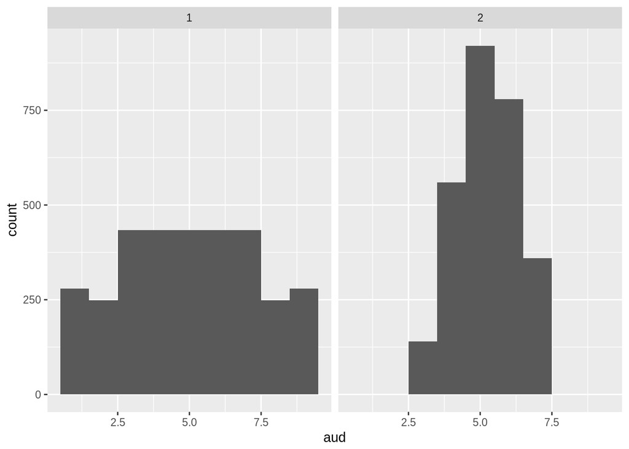

```r
ggplot(pretest, aes(x=aud)) +
  geom_histogram(breaks=seq(0.5,10)) +
  facet_grid(.~session)
```

## Category boundaries

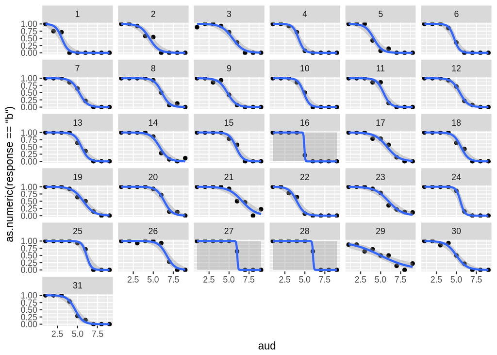

```r
pretest %>%
  filter(session == 1) %>%
  ggplot(aes(x=aud, y=as.numeric(response=='b'), group=subject)) +
  geom_point(stat='summary', fun.y=mean) +
  stat_smooth(method='glm', method.args=list(family='binomial')) +
  facet_wrap(~subject)
```

# Adaptation data

```r
dat_adapt <-
  files_adapt %>%
  map(read_file) %>%
  lift(bind_rows)()
```

The adaptation data has exposure and test trials mixed together in the same data files. They’re distinguished by their `movie` values: exposure movies are audio-visual stimuli (starting with “v” or “V”, followed by the visual category, the audio stimulus number, and (if present) the number of repetitions). The test trials have the same filenames as in the pretest: “bd0[1-9]n.wav”. We need to extract the number of repetitions for exposure trials, convert to cumulative exposures, and combine with the test trials. We also need to convert the source/movie filenames into the condition variables (ambiguity and visual category) and check for consistency.

## Source/movie consistency

```r
sessions <-
  dat_adapt %>%
  filter(str_detect(movie, "^[vV]")) %>%
  tidyr::extract(movie, c("movie_vid", "movie_aud"),
                 "[vV]([bd])a([0-9])", remove=FALSE, convert=TRUE) %>%
  tidyr::extract(source, c("source_vid", "source_aud"),
                 "[vV]([bd])a([0-9])", remove=FALSE, convert=TRUE)

mismatches <-
  sessions %>%
  group_by(source) %>%
  summarise_each(funs(unique), matches("(aud|vid)")) %>%
  filter((movie_vid != source_vid) | (movie_aud != source_aud))

mismatches %>% count(movie_aud, source_aud)
```

```
## Source: local data frame [5 x 3]
## Groups: movie_aud [?]
##
##   movie_aud source_aud     n
##       <int>      <int> <int>
## 1         1          5     1
## 2         1          9     1
## 3         4          5     7
## 4         6          1     1
## 5         6          5    86
```

```r
mismatches %>% count(movie_vid, source_vid)
```

```
## Source: local data frame [3 x 3]
## Groups: movie_vid [?]
##
##   movie_vid source_vid     n
##       <chr>      <chr> <int>
## 1         b          b    52
## 2         b          d     1
## 3         d          d    43
```

There are quite a few blocks where the movie and source information mismatch. Most of these are minor (the file says that `aud` is 5 but the movie is 4 or 6) but some are major (a prototypical 1 or 9 instead of an ambiguous 4, 5 or 6, and vice-versa). I’m inclined to trust the movie field since that’s formatted consistently, leading me to think it was generated by the experiment script, instead of the filenames which are much less consistent (and so probably done manually). But we’ll want to check the counterbalancing and ordering, too.

```r
sessions <-
  sessions %>%
  group_by(source, movie_vid, movie_aud, subject, session_time) %>%
  summarise() %>%
  rename(exposure_vid = movie_vid, exposure_aud = movie_aud) %>%
  group_by(subject) %>%
  mutate(session = rank(session_time),
         exposure_vid = factor(exposure_vid),
         ambiguous = factor(ifelse(exposure_aud %in% c(1,9),
                                   "prototypical",
                                   "ambiguous"),
                            levels = c("prototypical", "ambiguous"))) %>%
  arrange(subject, session)
```

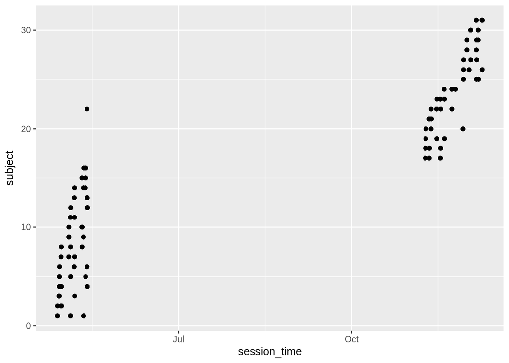

```r
sessions %>%
  ggplot(aes(x=session_time, y=subject)) +
  geom_point()
```

## Extracting exposure trials

The exposure and test trials are mixed together. We need to know the cumulative exposures for each test trial, so we need to pull out the repetitions on each exposure movie and compute a cumulative sum.

```r
extract_exposures <- function(movie) {
  is_exposure <- str_detect(movie, "^[vV]")
  reps <- str_match(movie, "R([0-9]+)")[, 2] %>% as.double()
  ifelse(
    is_exposure,
    ifelse(
      is.na(reps),
      1,
      reps),
    0)
}

## add cumulative exposure counts, conditions, and session info to test trials
adapt <-
  dat_adapt %>%
  mutate(exposures = extract_exposures(movie)) %>%
  group_by(source) %>%
  mutate(exposures = cumsum(exposures)) %>%
  # get rid of exposure trials
  filter(!str_detect(movie, "^[vV]")) %>%
  # pull out test stimulus continuum number
  tidyr::extract(movie, "aud", "bd([0-9]*)", convert=TRUE) %>%
  # combine with session metadata (condition, time, and session order)
  left_join(sessions) %>%
  ungroup()
```

# Save it

```r
pretest_ambig <- pretest %>% filter(session == 2) %>% mutate(session=NULL)
pretest <- pretest %>% filter(session == 1) %>% mutate(session=NULL)

devtools::use_data(pretest, pretest_ambig, adapt, overwrite=TRUE)
```

```
## Saving pretest, pretest_ambig, adapt as pretest.rda, pretest_ambig.rda, adapt.rda to /home/dave/data/vroomen07/data
```